# Evaluation of example datasets from Attachment 1 to the US EPA SOP for the NAFTA guidance

Johannes Ranke

26 February 2019 (rebuilt 2021-02-15)

# Introduction

In this document, the example evaluations provided in Attachment 1 to the SOP of US EPA for using the NAFTA guidance (US EPA 2015) are repeated using mkin. The original evaluations reported in the attachment were performed using PestDF in version 0.8.4. Note that PestDF 0.8.13 is the version distributed at the US EPA website today (2019-02-26).

The datasets are now distributed with the mkin package.

# Examples where DFOP did not converge with PestDF 0.8.4

In attachment 1, it is reported that the DFOP model does not converge for these datasets when PestDF 0.8.4 was used. For all four datasets, the DFOP model can be fitted with mkin (see below). The negative half-life given by PestDF 0.8.4 for these fits appears to be the result of a bug. The results for the other two models (SFO and IORE) are the same.

## Example on page 5, upper panel

```r
p5a <- nafta(NAFTA_SOP_Attachment[["p5a"]])
```

```
## The SFO model is rejected as S_SFO is equal or higher than the critical value S_c
```

```
## The half-life obtained from the IORE model may be used
```

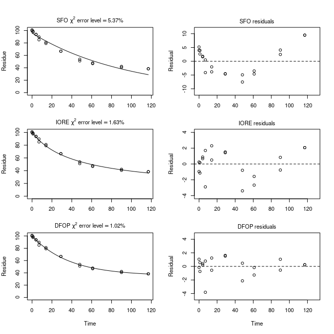

```r
plot(p5a)
```

```r
print(p5a)
```

```
## Sums of squares:
##     SFO    IORE    DFOP
## 465.218  56.275  32.064
##
## Critical sum of squares for checking the SFO model:
## [1] 64.43
##
## Parameters:
## $SFO
##          Estimate   Pr(>t)  Lower   Upper
## parent_0  95.8401 4.67e-21 92.245 99.4357
## k_parent   0.0102 3.92e-12  0.009  0.0117
## sigma      4.8230 3.81e-06  3.214  6.4318
##
## $IORE
##                Estimate Pr(>t)    Lower    Upper
## parent_0       1.01e+02     NA 9.91e+01 1.02e+02
## k__iore_parent 1.54e-05     NA 4.08e-06 5.84e-05
## N_parent       2.57e+00     NA 2.25e+00 2.89e+00
## sigma          1.68e+00     NA 1.12e+00 2.24e+00
##
## $DFOP
##          Estimate   Pr(>t)   Lower    Upper
## parent_0 9.99e+01 1.41e-26 98.8116 101.0810
## k1       2.67e-02 5.05e-06  0.0243   0.0295
## k2       2.26e-12 5.00e-01  0.0000      Inf
## g        6.47e-01 3.67e-06  0.6248   0.6677
## sigma    1.27e+00 8.91e-06  0.8395   1.6929
##
##
## DTx values:
##      DT50     DT90 DT50_rep
## SFO  67.7 2.25e+02 6.77e+01
## IORE 58.2 1.07e+03 3.22e+02
## DFOP 55.5 5.59e+11 3.07e+11
##
## Representative half-life:
## [1] 321.51
```

## Example on page 5, lower panel

```r
p5b <- nafta(NAFTA_SOP_Attachment[["p5b"]])
```

```
## The SFO model is rejected as S_SFO is equal or higher than the critical value S_c
```

```
## The half-life obtained from the IORE model may be used
```

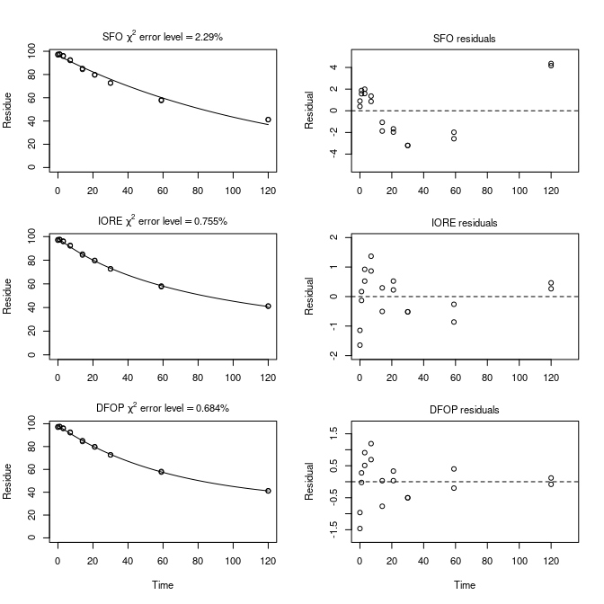

```r
plot(p5b)
```

```r
print(p5b)
```

```
## Sums of squares:
##     SFO    IORE    DFOP
## 94.8112 10.1094  7.5587
##
## Critical sum of squares for checking the SFO model:
## [1] 11.779
##
## Parameters:
## $SFO
##          Estimate   Pr(>t)    Lower    Upper
## parent_0   96.497 2.32e-24 94.85271 98.14155
## k_parent    0.008 3.42e-14  0.00737  0.00869
## sigma       2.295 1.22e-05  1.47976  3.11036
##
## $IORE
##                Estimate   Pr(>t)    Lower    Upper
## parent_0       9.85e+01 1.17e-28 9.79e+01 9.92e+01
## k__iore_parent 1.53e-04 6.50e-03 7.21e-05 3.26e-04
## N_parent       1.94e+00 5.88e-13 1.76e+00 2.12e+00
## sigma          7.49e-01 1.63e-05 4.82e-01 1.02e+00
##
## $DFOP
##          Estimate   Pr(>t)   Lower   Upper
## parent_0 9.84e+01 1.24e-27 97.8078 98.9187
## k1       1.55e-02 4.10e-04  0.0143  0.0167
## k2       8.63e-12 5.00e-01  0.0000     Inf
## g        6.89e-01 2.92e-03  0.6626  0.7142
## sigma    6.48e-01 2.38e-05  0.4147  0.8813
##
##
## DTx values:
##      DT50     DT90 DT50_rep
## SFO  86.6 2.88e+02 8.66e+01
## IORE 85.5 7.17e+02 2.16e+02
## DFOP 83.6 1.32e+11 8.04e+10
##
## Representative half-life:
## [1] 215.87
```

## Example on page 6

```r
p6 <- nafta(NAFTA_SOP_Attachment[["p6"]])
```

```
## The SFO model is rejected as S_SFO is equal or higher than the critical value S_c
```

```
## The half-life obtained from the IORE model may be used
```

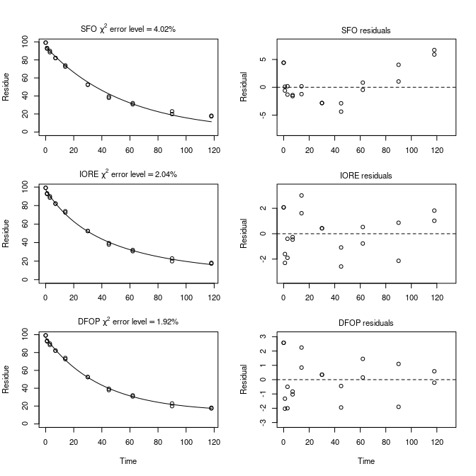

```r
plot(p6)
```

```r
print(p6)
```

```
## Sums of squares:
##     SFO    IORE    DFOP
## 188.454  51.007  42.469
##
## Critical sum of squares for checking the SFO model:
## [1] 58.399
##
## Parameters:
## $SFO
##          Estimate   Pr(>t)   Lower   Upper
## parent_0  94.7759 7.29e-24 92.3478 97.2039
## k_parent   0.0179 8.02e-16  0.0166  0.0194
## sigma      3.0696 3.81e-06  2.0456  4.0936
##
## $IORE
##                Estimate   Pr(>t)    Lower    Upper
## parent_0       97.12446 2.63e-26 95.62461 98.62431
## k__iore_parent  0.00252 1.95e-03  0.00134  0.00472
## N_parent        1.49587 4.07e-13  1.33896  1.65279
## sigma           1.59698 5.05e-06  1.06169  2.13227
##
## $DFOP
##          Estimate   Pr(>t)   Lower   Upper
## parent_0 9.66e+01 1.57e-25 95.3476 97.8979
## k1       2.55e-02 7.33e-06  0.0233  0.0278
## k2       3.22e-11 5.00e-01  0.0000     Inf
## g        8.61e-01 7.55e-06  0.8314  0.8867
## sigma    1.46e+00 6.93e-06  0.9661  1.9483
##
##
## DTx values:
##      DT50     DT90 DT50_rep
## SFO  38.6 1.28e+02 3.86e+01
## IORE 34.0 1.77e+02 5.32e+01
## DFOP 34.1 1.01e+10 2.15e+10
##
## Representative half-life:
## [1] 53.17
```

## Example on page 7

```r
p7 <- nafta(NAFTA_SOP_Attachment[["p7"]])
```

```
## The SFO model is rejected as S_SFO is equal or higher than the critical value S_c
```

```
## The half-life obtained from the IORE model may be used
```

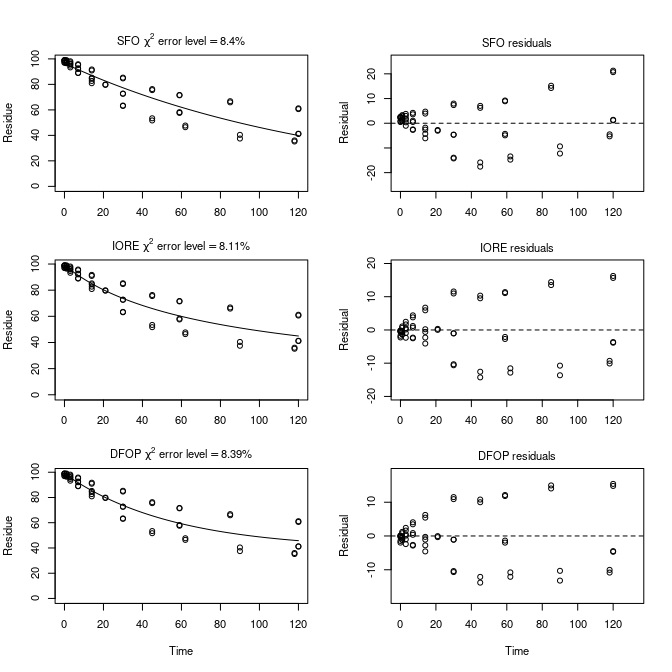

```r
plot(p7)
```

```r
print(p7)
```

```
## Sums of squares:
##    SFO   IORE   DFOP
## 3661.7 3195.0 3174.1
##
## Critical sum of squares for checking the SFO model:
## [1] 3334.2
##
## Parameters:
## $SFO
##          Estimate   Pr(>t)    Lower    Upper
## parent_0 96.41796 4.80e-53 93.32245 99.51347
## k_parent  0.00735 7.64e-21  0.00641  0.00843
## sigma     7.94557 1.83e-15  6.46713  9.42401
##
## $IORE
##                Estimate Pr(>t)    Lower    Upper
## parent_0       9.92e+01     NA 9.55e+01 1.03e+02
## k__iore_parent 1.60e-05     NA 1.45e-07 1.77e-03
## N_parent       2.45e+00     NA 1.35e+00 3.54e+00
## sigma          7.42e+00     NA 6.04e+00 8.80e+00
##
## $DFOP
##          Estimate   Pr(>t)   Lower    Upper
## parent_0 9.89e+01 9.44e-49 95.4640 102.2573
## k1       1.81e-02 1.75e-01  0.0116   0.0281
## k2       3.63e-10 5.00e-01  0.0000      Inf
## g        6.06e-01 2.19e-01  0.4826   0.7178
## sigma    7.40e+00 2.97e-15  6.0201   8.7754
##
##
## DTx values:
##      DT50     DT90 DT50_rep
## SFO  94.3 3.13e+02 9.43e+01
## IORE 96.7 1.51e+03 4.55e+02
## DFOP 96.4 3.77e+09 1.91e+09
##
## Representative half-life:
## [1] 454.55
```

# Examples where the representative half-life deviates from the observed DT50

## Example on page 8

For this dataset, the IORE fit does not converge when the default starting values used by mkin for the IORE model are used. Therefore, a lower value for the rate constant is used here.

```r
p8 <- nafta(NAFTA_SOP_Attachment[["p8"]], parms.ini = c(k__iore_parent = 1e-3))
```

```
## The SFO model is rejected as S_SFO is equal or higher than the critical value S_c
```

```
## The half-life obtained from the IORE model may be used
```

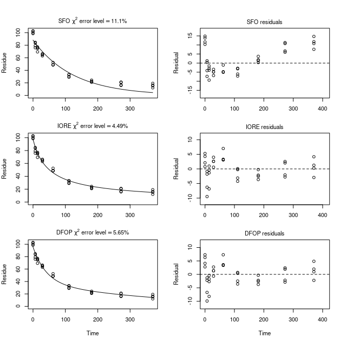

```r
plot(p8)
```

```r
print(p8)
```

```
## Sums of squares:
##     SFO    IORE    DFOP
## 1996.94  444.92  547.56
##
## Critical sum of squares for checking the SFO model:
## [1] 477.49
##
## Parameters:
## $SFO
##          Estimate   Pr(>t)    Lower    Upper
## parent_0 88.16549 6.53e-29 83.37344 92.95754
## k_parent  0.00803 1.67e-13  0.00674  0.00957
## sigma     7.44786 4.17e-10  5.66209  9.23363
##
## $IORE
##                Estimate   Pr(>t)    Lower    Upper
## parent_0       9.77e+01 7.03e-35 9.44e+01 1.01e+02
## k__iore_parent 6.14e-05 3.20e-02 2.12e-05 1.78e-04
## N_parent       2.27e+00 4.23e-18 2.00e+00 2.54e+00
## sigma          3.52e+00 5.36e-10 2.67e+00 4.36e+00
##
## $DFOP
##          Estimate   Pr(>t)    Lower    Upper
## parent_0 95.70619 8.99e-32 91.87941 99.53298
## k1        0.02500 5.25e-04  0.01422  0.04394
## k2        0.00273 6.84e-03  0.00125  0.00597
## g         0.58835 2.84e-06  0.36595  0.77970
## sigma     3.90001 6.94e-10  2.96260  4.83741
##
##
## DTx values:
##      DT50 DT90 DT50_rep
## SFO  86.3  287     86.3
## IORE 53.4  668    201.0
## DFOP 55.6  517    253.0
##
## Representative half-life:
## [1] 201.03
```

# Examples where SFO was not selected for an abiotic study

## Example on page 9, upper panel

```r
p9a <- nafta(NAFTA_SOP_Attachment[["p9a"]])
```

```
## The SFO model is rejected as S_SFO is equal or higher than the critical value S_c
```

```
## The half-life obtained from the IORE model may be used
```

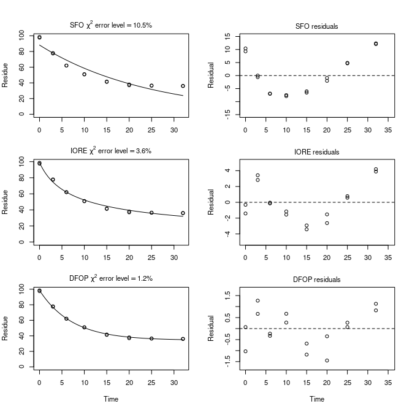

```r
plot(p9a)
```

```r
print(p9a)
```

```
## Sums of squares:
##      SFO     IORE     DFOP
## 839.3524  88.5706   9.9336
##
## Critical sum of squares for checking the SFO model:
## [1] 105.57
##
## Parameters:
## $SFO
##          Estimate   Pr(>t)   Lower   Upper
## parent_0  88.1933 3.06e-12 79.9447 96.4419
## k_parent   0.0409 2.07e-07  0.0324  0.0516
## sigma      7.2429 3.92e-05  4.4768 10.0090
##
## $IORE
##                Estimate   Pr(>t)    Lower    Upper
## parent_0       9.89e+01 1.12e-16 9.54e+01 1.02e+02
## k__iore_parent 1.93e-05 1.13e-01 3.49e-06 1.06e-04
## N_parent       2.91e+00 1.45e-09 2.50e+00 3.32e+00
## sigma          2.35e+00 5.31e-05 1.45e+00 3.26e+00
##
## $DFOP
##          Estimate   Pr(>t)  Lower  Upper
## parent_0 9.85e+01 2.54e-20 97.390 99.672
## k1       1.38e-01 3.52e-05  0.131  0.146
## k2       9.02e-13 5.00e-01  0.000    Inf
## g        6.52e-01 8.13e-06  0.642  0.661
## sigma    7.88e-01 6.13e-02  0.481  1.095
##
##
## DTx values:
##      DT50     DT90 DT50_rep
## SFO  16.9 5.63e+01 1.69e+01
## IORE 11.6 3.37e+02 1.01e+02
## DFOP 10.5 1.38e+12 7.69e+11
##
## Representative half-life:
## [1] 101.43
```

In this example, the residuals of the SFO indicate a lack of fit of this model, so even if it was an abiotic experiment, the data do not suggest a simple exponential decline.

## Example on page 9, lower panel

```r
p9b <- nafta(NAFTA_SOP_Attachment[["p9b"]])
```

```
## The SFO model is rejected as S_SFO is equal or higher than the critical value S_c
```

```
## The half-life obtained from the IORE model may be used
```

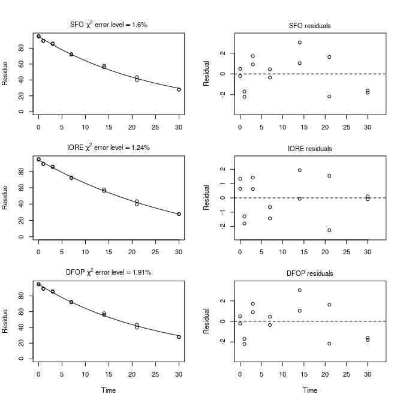

```r
plot(p9b)
```

```r
print(p9b)
```

```
## Sums of squares:
##    SFO   IORE   DFOP
## 35.649 23.223 35.649
##
## Critical sum of squares for checking the SFO model:
## [1] 28.542
##
## Parameters:
## $SFO
##          Estimate   Pr(>t)  Lower   Upper
## parent_0  94.7123 2.15e-19 93.178 96.2464
## k_parent   0.0389 4.47e-14  0.037  0.0408
## sigma      1.5957 1.28e-04  0.932  2.2595
##
## $IORE
##                Estimate   Pr(>t)   Lower  Upper
## parent_0         93.863 2.32e-18 92.4565 95.269
## k__iore_parent    0.127 1.85e-02  0.0504  0.321
## N_parent          0.711 1.88e-05  0.4843  0.937
## sigma             1.288 1.76e-04  0.7456  1.830
##
## $DFOP
##          Estimate   Pr(>t)   Lower   Upper
## parent_0  94.7123 1.61e-16 93.1355 96.2891
## k1         0.0389 1.08e-04  0.0266  0.0569
## k2         0.0389 2.23e-04  0.0255  0.0592
## g          0.5256      NaN      NA      NA
## sigma      1.5957 2.50e-04  0.9135  2.2779
##
##
## DTx values:
##      DT50 DT90 DT50_rep
## SFO  17.8 59.2     17.8
## IORE 18.4 49.2     14.8
## DFOP 17.8 59.2     17.8
##
## Representative half-life:
## [1] 14.8
```

Here, mkin gives a longer slow DT50 for the DFOP model (17.8 days) than PestDF (13.5 days). Presumably, this is related to the fact that PestDF gives a negative value for the proportion of the fast degradation which should be between 0 and 1, inclusive. This parameter is called f in PestDF and g in mkin. In mkin, it is restricted to the interval from 0 to 1.

## Example on page 10

```r
p10 <- nafta(NAFTA_SOP_Attachment[["p10"]])
```

```
## The SFO model is rejected as S_SFO is equal or higher than the critical value S_c
```

```
## The half-life obtained from the IORE model may be used
```

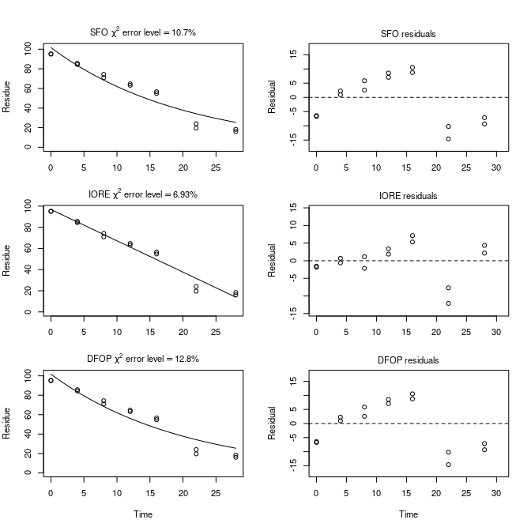

```r
plot(p10)
```

```r
print(p10)
```

```
## Sums of squares:
##    SFO   IORE   DFOP
## 899.41 336.43 899.41
##
## Critical sum of squares for checking the SFO model:
## [1] 413.48
##
## Parameters:
## $SFO
##          Estimate   Pr(>t)   Lower    Upper
## parent_0 101.7315 6.42e-11 91.9259 111.5371
## k_parent   0.0495 1.70e-07  0.0404   0.0607
## sigma      8.0152 1.28e-04  4.6813  11.3491
##
## $IORE
##                Estimate   Pr(>t)  Lower   Upper
## parent_0          96.86 3.32e-12 90.848 102.863
## k__iore_parent     2.96 7.91e-02  0.687  12.761
## N_parent           0.00 5.00e-01 -0.372   0.372
## sigma              4.90 1.77e-04  2.837   6.968
##
## $DFOP
##          Estimate   Pr(>t)   Lower    Upper
## parent_0 101.7315 1.41e-09 91.6534 111.8097
## k1         0.0495 6.58e-03  0.0303   0.0809
## k2         0.0495 2.60e-03  0.0410   0.0598
## g          0.4487 5.00e-01      NA       NA
## sigma      8.0152 2.50e-04  4.5886  11.4418
##
##
## DTx values:
##      DT50 DT90 DT50_rep
## SFO  14.0 46.5    14.00
## IORE 16.4 29.4     8.86
## DFOP 14.0 46.5    14.00
##
## Representative half-life:
## [1] 8.86
```

Here, a value below N is given for the IORE model, because the data suggests a faster decline towards the end of the experiment, which appears physically rather unlikely in the case of a photolysis study. It seems PestDF does not constrain N to values above zero, thus the slight difference in IORE model parameters between PestDF and mkin.

# The DT50 was not observed during the study

## Example on page 11

```r
p11 <- nafta(NAFTA_SOP_Attachment[["p11"]])
```

```
## The SFO model is rejected as S_SFO is equal or higher than the critical value S_c
```

```
## The half-life obtained from the IORE model may be used
```

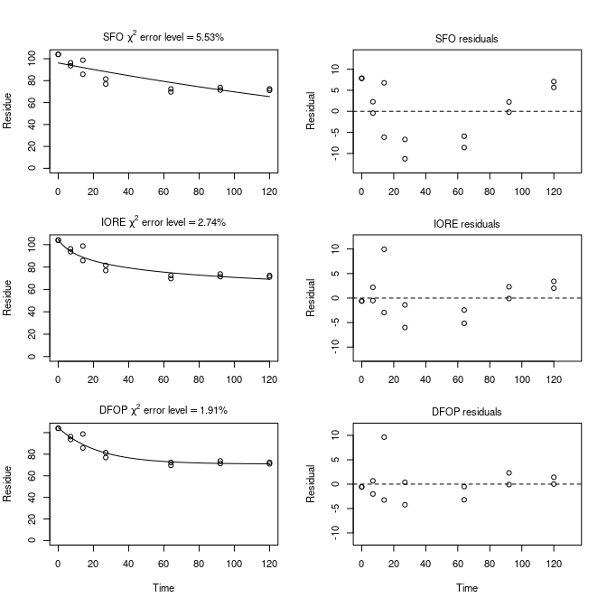

```r
plot(p11)
```

```r
print(p11)
```

```
## Sums of squares:
##    SFO   IORE   DFOP
## 579.68 204.79 144.78
##
## Critical sum of squares for checking the SFO model:
## [1] 251.69
##
## Parameters:
## $SFO
##          Estimate   Pr(>t)    Lower    Upper
## parent_0 96.15820 4.83e-13 90.24934 1.02e+02
## k_parent  0.00321 4.71e-05  0.00222 4.64e-03
## sigma     6.43473 1.28e-04  3.75822 9.11e+00
##
## $IORE
##                Estimate Pr(>t)    Lower    Upper
## parent_0       1.05e+02     NA 9.90e+01 1.10e+02
## k__iore_parent 3.11e-17     NA 1.35e-20 7.18e-14
## N_parent       8.36e+00     NA 6.62e+00 1.01e+01
## sigma          3.82e+00     NA 2.21e+00 5.44e+00
##
## $DFOP
##          Estimate   Pr(>t)    Lower    Upper
## parent_0 1.05e+02 9.47e-13  99.9990 109.1224
## k1       4.41e-02 5.95e-03   0.0296   0.0658
## k2       9.94e-13 5.00e-01   0.0000      Inf
## g        3.22e-01 1.45e-03   0.2814   0.3650
## sigma    3.22e+00 3.52e-04   1.8410   4.5906
##
##
## DTx values:
##          DT50     DT90 DT50_rep
## SFO  2.16e+02 7.18e+02 2.16e+02
## IORE 9.73e+02 1.37e+08 4.11e+07
## DFOP 3.07e+11 1.93e+12 6.98e+11
##
## Representative half-life:
## [1] 41148170
```

In this case, the DFOP fit reported for PestDF resulted in a negative value for the slower rate constant, which is not possible in mkin. The other results are in agreement.

# N is less than 1 and the DFOP rate constants are like the SFO rate constant

In the following three examples, the same results are obtained with mkin as reported for PestDF. As in the case on page 10, the N values below 1 are deemed unrealistic and appear to be the result of an overparameterisation.

## Example on page 12, upper panel

```r
p12a <- nafta(NAFTA_SOP_Attachment[["p12a"]])
```

```
## The SFO model is rejected as S_SFO is equal or higher than the critical value S_c
```

```
## The half-life obtained from the IORE model may be used
```

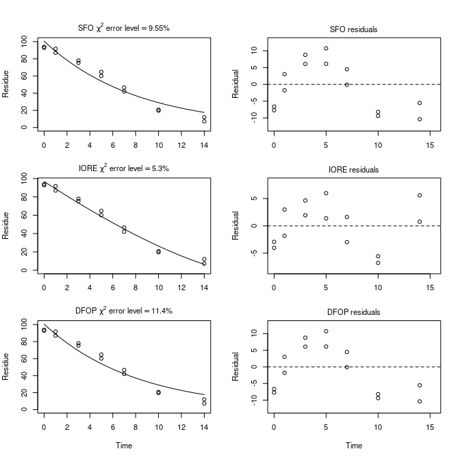

```r
plot(p12a)
```

```r
print(p12a)
```

```
## Sums of squares:
##    SFO   IORE   DFOP
## 695.44 220.07 695.44
##
## Critical sum of squares for checking the SFO model:
## [1] 270.47
##
## Parameters:
## $SFO
##          Estimate   Pr(>t)  Lower   Upper
## parent_0  100.521 8.75e-12 92.461 108.581
## k_parent    0.124 3.61e-08  0.104   0.148
## sigma       7.048 1.28e-04  4.116   9.980
##
## $IORE
##                Estimate Pr(>t) Lower Upper
## parent_0         96.823     NA    NA    NA
## k__iore_parent    2.436     NA    NA    NA
## N_parent          0.263     NA    NA    NA
## sigma             3.965     NA    NA    NA
##
## $DFOP
##          Estimate   Pr(>t)   Lower   Upper
## parent_0  100.521 2.74e-10 92.2366 108.805
## k1          0.124 2.53e-05  0.0908   0.170
## k2          0.124 2.52e-02  0.0456   0.339
## g           0.793      NaN      NA      NA
## sigma       7.048 2.50e-04  4.0349  10.061
##
##
## DTx values:
##      DT50 DT90 DT50_rep
## SFO  5.58 18.5     5.58
## IORE 6.49 13.2     3.99
## DFOP 5.58 18.5     5.58
##
## Representative half-life:
## [1] 3.99
```

## Example on page 12, lower panel

```r
p12b <- nafta(NAFTA_SOP_Attachment[["p12b"]])
```

```
## The SFO model is rejected as S_SFO is equal or higher than the critical value S_c
```

```
## The half-life obtained from the IORE model may be used
```

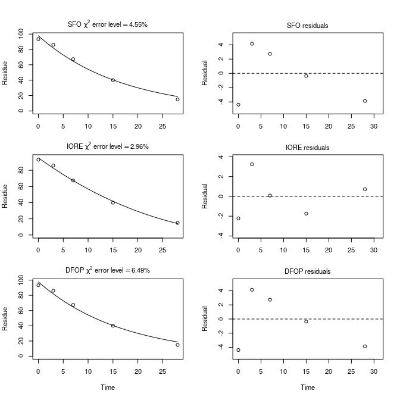

```r
plot(p12b)
```

```r
print(p12b)
```

```
## Sums of squares:
##    SFO   IORE   DFOP
## 58.902 19.064 58.902
##
## Critical sum of squares for checking the SFO model:
## [1] 51.518
##
## Parameters:
## $SFO
##          Estimate  Pr(>t)   Lower    Upper
## parent_0  97.6840 0.00039 85.9388 109.4292
## k_parent   0.0589 0.00261  0.0431   0.0805
## sigma      3.4323 0.04356 -1.2377   8.1023
##
## $IORE
##                Estimate Pr(>t)     Lower  Upper
## parent_0         95.523 0.0055 74.539157 116.51
## k__iore_parent    0.333 0.1433  0.000717 154.57
## N_parent          0.568 0.0677 -0.989464   2.13
## sigma             1.953 0.0975 -5.893100   9.80
##
## $DFOP
##          Estimate Pr(>t) Lower Upper
## parent_0  97.6840    NaN   NaN   NaN
## k1         0.0589    NaN    NA    NA
## k2         0.0589    NaN    NA    NA
## g          0.6473    NaN    NA    NA
## sigma      3.4323    NaN   NaN   NaN
##
##
## DTx values:
##      DT50 DT90 DT50_rep
## SFO  11.8 39.1    11.80
## IORE 12.9 31.4     9.46
## DFOP 11.8 39.1    11.80
##
## Representative half-life:
## [1] 9.46
```

## Example on page 13

```r
p13 <- nafta(NAFTA_SOP_Attachment[["p13"]])
```

```
## The SFO model is rejected as S_SFO is equal or higher than the critical value S_c
```

```
## The half-life obtained from the IORE model may be used
```

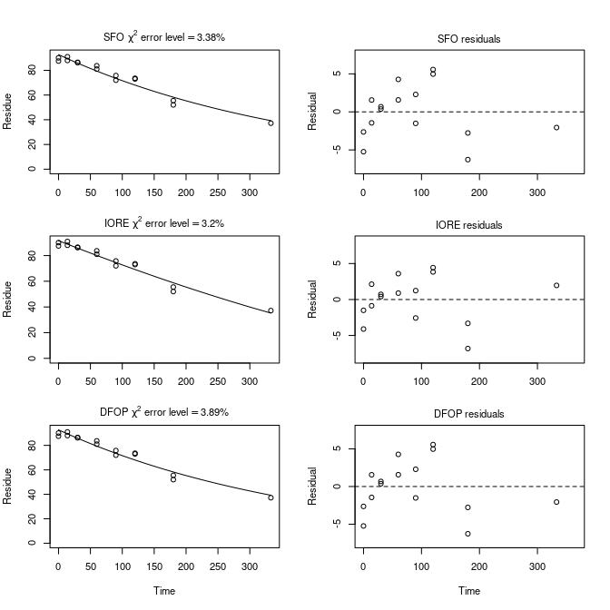

```r
plot(p13)
```

```r
print(p13)
```

```
## Sums of squares:
##   SFO  IORE  DFOP
## 174.6 142.4 174.6
##
## Critical sum of squares for checking the SFO model:
## [1] 172.13
##
## Parameters:
## $SFO
##          Estimate   Pr(>t)    Lower    Upper
## parent_0 92.73500 5.99e-17 89.61936 95.85065
## k_parent  0.00258 2.42e-09  0.00223  0.00299
## sigma     3.41172 7.07e-05  2.05455  4.76888
##
## $IORE
##                Estimate   Pr(>t)    Lower  Upper
## parent_0        91.6016 6.34e-16 88.53086 94.672
## k__iore_parent   0.0396 2.36e-01  0.00207  0.759
## N_parent         0.3541 1.46e-01 -0.35153  1.060
## sigma            3.0811 9.64e-05  1.84296  4.319
##
## $DFOP
##          Estimate Pr(>t)    Lower    Upper
## parent_0 92.73500     NA 8.95e+01 95.92118
## k1        0.00258     NA 4.14e-04  0.01611
## k2        0.00258     NA 1.74e-03  0.00383
## g         0.16452     NA 0.00e+00  1.00000
## sigma     3.41172     NA 2.02e+00  4.79960
##
##
## DTx values:
##      DT50 DT90 DT50_rep
## SFO   269  892      269
## IORE  261  560      169
## DFOP  269  892      269
##
## Representative half-life:
## [1] 168.51
```

# DT50 not observed in the study and DFOP problems in PestDF

```r
p14 <- nafta(NAFTA_SOP_Attachment[["p14"]])
```

```
## The SFO model is rejected as S_SFO is equal or higher than the critical value S_c
```

```
## The half-life obtained from the IORE model may be used
```

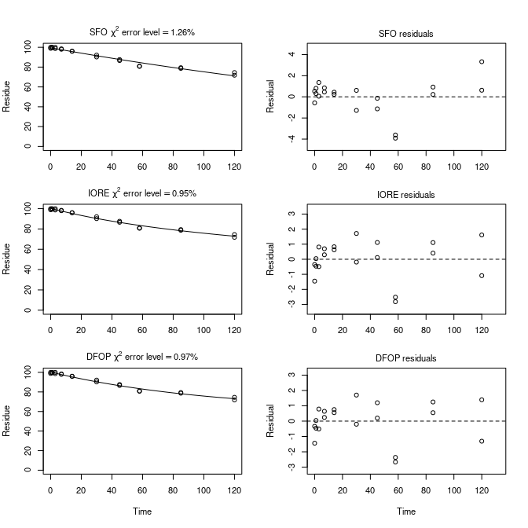

```r
plot(p14)
```

```r
print(p14)
```

```
## Sums of squares:
##    SFO   IORE   DFOP
## 48.432 28.677 27.262
##
## Critical sum of squares for checking the SFO model:
## [1] 32.833
##
## Parameters:
## $SFO
##          Estimate   Pr(>t)    Lower    Upper
## parent_0 99.47124 2.06e-30 98.42254 1.01e+02
## k_parent  0.00279 3.75e-15  0.00256 3.04e-03
## sigma     1.55616 3.81e-06  1.03704 2.08e+00
##
## $IORE
##                Estimate Pr(>t) Lower Upper
## parent_0       1.00e+02     NA   NaN   NaN
## k__iore_parent 9.44e-08     NA   NaN   NaN
## N_parent       3.31e+00     NA   NaN   NaN
## sigma          1.20e+00     NA 0.796   1.6
##
## $DFOP
##          Estimate   Pr(>t)    Lower    Upper
## parent_0 1.00e+02 2.96e-28 99.40280 101.2768
## k1       9.53e-03 1.20e-01  0.00638   0.0143
## k2       6.08e-12 5.00e-01  0.00000      Inf
## g        3.98e-01 2.19e-01  0.30481   0.4998
## sigma    1.17e+00 7.68e-06  0.77406   1.5610
##
##
## DTx values:
##          DT50     DT90 DT50_rep
## SFO  2.48e+02 8.25e+02 2.48e+02
## IORE 4.34e+02 2.22e+04 6.70e+03
## DFOP 3.05e+10 2.95e+11 1.14e+11
##
## Representative half-life:
## [1] 6697.4
```

The slower rate constant reported by PestDF is negative, which is not physically realistic, and not possible in mkin. The other fits give the same results in mkin and PestDF.

# N is less than 1 and DFOP fraction parameter is below zero

```r
p15a <- nafta(NAFTA_SOP_Attachment[["p15a"]])
```

```
## The SFO model is rejected as S_SFO is equal or higher than the critical value S_c
```

```
## The half-life obtained from the IORE model may be used
```

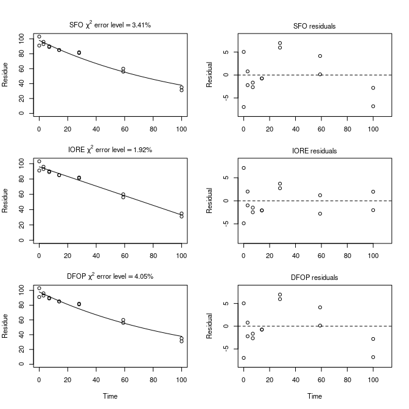

```r
plot(p15a)
```

```r
print(p15a)
```

```
## Sums of squares:
##    SFO   IORE   DFOP
## 245.52 135.01 245.52
##
## Critical sum of squares for checking the SFO model:
## [1] 165.93
##
## Parameters:
## $SFO
##          Estimate   Pr(>t)    Lower   Upper
## parent_0 97.96751 2.00e-15 94.32049 101.615
## k_parent  0.00952 4.93e-09  0.00824   0.011
## sigma     4.18778 1.28e-04  2.44588   5.930
##
## $IORE
##                Estimate   Pr(>t)  Lower  Upper
## parent_0         95.874 2.94e-15 92.937 98.811
## k__iore_parent    0.629 2.11e-01  0.044  8.982
## N_parent          0.000 5.00e-01 -0.642  0.642
## sigma             3.105 1.78e-04  1.795  4.416
##
## $DFOP
##          Estimate   Pr(>t)    Lower    Upper
## parent_0 97.96751 2.85e-13 94.21913 101.7159
## k1        0.00952 6.28e-02  0.00250   0.0363
## k2        0.00952 1.27e-04  0.00646   0.0140
## g         0.21241 5.00e-01  0.00000   1.0000
## sigma     4.18778 2.50e-04  2.39747   5.9781
##
##
## DTx values:
##      DT50 DT90 DT50_rep
## SFO  72.8  242     72.8
## IORE 76.3  137     41.3
## DFOP 72.8  242     72.8
##
## Representative half-life:
## [1] 41.33
```

```r
p15b <- nafta(NAFTA_SOP_Attachment[["p15b"]])
```

```
## The SFO model is rejected as S_SFO is equal or higher than the critical value S_c
```

```
## The half-life obtained from the IORE model may be used
```

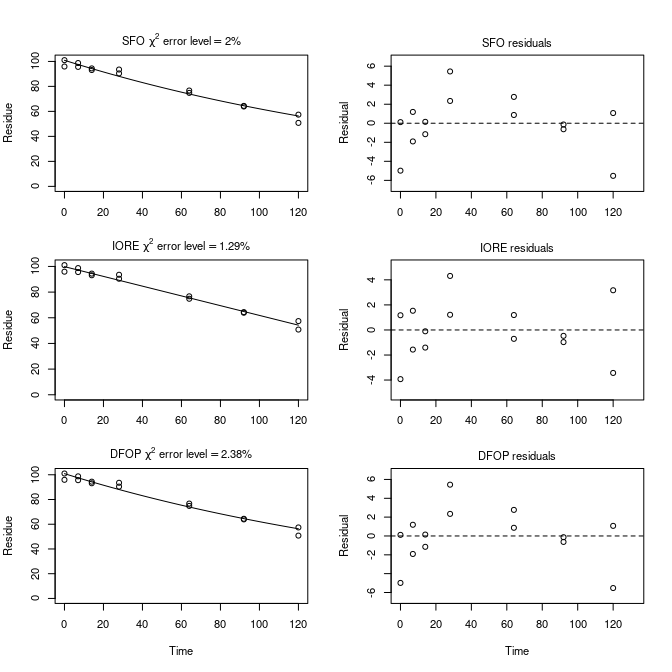

```r
plot(p15b)
```

```r
print(p15b)
```

```
## Sums of squares:
##     SFO    IORE    DFOP
## 106.916  68.556 106.916
##
## Critical sum of squares for checking the SFO model:
## [1] 84.256
##
## Parameters:
## $SFO
##          Estimate   Pr(>t)    Lower    Upper
## parent_0 1.01e+02 3.06e-17 98.31594 1.03e+02
## k_parent 4.86e-03 2.48e-10  0.00435 5.42e-03
## sigma    2.76e+00 1.28e-04  1.61402 3.91e+00
##
## $IORE
##                Estimate   Pr(>t)    Lower  Upper
## parent_0          99.83 1.81e-16 97.51349 102.14
## k__iore_parent     0.38 3.22e-01  0.00352  41.05
## N_parent           0.00 5.00e-01 -1.07696   1.08
## sigma              2.21 2.57e-04  1.23245   3.19
##
## $DFOP
##          Estimate Pr(>t)    Lower    Upper
## parent_0 1.01e+02     NA 9.82e+01 1.04e+02
## k1       4.86e-03     NA 8.63e-04 2.73e-02
## k2       4.86e-03     NA 3.21e-03 7.35e-03
## g        1.88e-01     NA       NA       NA
## sigma    2.76e+00     NA 1.58e+00 3.94e+00
##
##
## DTx values:
##      DT50 DT90 DT50_rep
## SFO   143  474    143.0
## IORE  131  236     71.2
## DFOP  143  474    143.0
##
## Representative half-life:
## [1] 71.18
```

In mkin, only the IORE fit is affected (deemed unrealistic), as the fraction parameter of the DFOP model is restricted to the interval between 0 and 1 in mkin. The SFO fits give the same results for both mkin and PestDF.

# The DFOP fraction parameter is greater than 1

```r
p16 <- nafta(NAFTA_SOP_Attachment[["p16"]])
```

```
## The SFO model is rejected as S_SFO is equal or higher than the critical value S_c
```

```
## The representative half-life of the IORE model is longer than the one corresponding
```

```
## to the terminal degradation rate found with the DFOP model.
```

```
## The representative half-life obtained from the DFOP model may be used
```

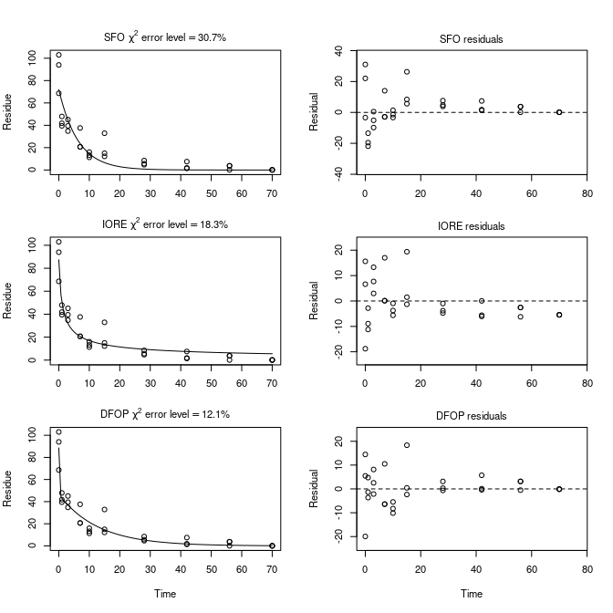

```r
plot(p16)
```

```r
print(p16)
```

```
## Sums of squares:
##    SFO   IORE   DFOP
## 3831.8 2062.0 1551.0
##
## Critical sum of squares for checking the SFO model:
## [1] 2247.3
##
## Parameters:
## $SFO
##          Estimate   Pr(>t)  Lower Upper
## parent_0   71.953 2.33e-13 60.509 83.40
## k_parent    0.159 4.86e-05  0.102  0.25
## sigma      11.302 1.25e-08  8.308 14.30
##
## $IORE
##                Estimate   Pr(>t)    Lower    Upper
## parent_0       8.74e+01 2.48e-16 7.72e+01 97.52972
## k__iore_parent 4.55e-04 2.16e-01 3.48e-05  0.00595
## N_parent       2.70e+00 1.21e-08 1.99e+00  3.40046
## sigma          8.29e+00 1.61e-08 6.09e+00 10.49062
##
## $DFOP
##          Estimate   Pr(>t)   Lower  Upper
## parent_0  88.5333 7.40e-18 79.9836 97.083
## k1        18.8461 5.00e-01  0.0000    Inf
## k2         0.0776 1.41e-05  0.0518  0.116
## g          0.4733 1.41e-09  0.3674  0.582
## sigma      7.1902 2.11e-08  5.2785  9.102
##
##
## DTx values:
##      DT50 DT90 DT50_rep
## SFO  4.35 14.4     4.35
## IORE 1.48 32.1     9.67
## DFOP 0.67 21.4     8.93
##
## Representative half-life:
## [1] 8.93
```

# Conclusions

The results obtained with mkin deviate from the results obtained with PestDF either in cases where one of the interpretive rules would apply, i.e. the IORE parameter N is less than one or the DFOP k values obtained with PestDF are equal to the SFO k values, or in cases where the DFOP model did not converge, which often lead to negative rate constants returned by PestDF.

Therefore, mkin appears to suitable for kinetic evaluations according to the NAFTA guidance.

# References

US EPA. 2015. “Standard Operating Procedure for Using the NAFTA Guidance to Calculate Representative Half-Life Values and Characterizing Pesticide Degradation.”